# Anomia y alineación en el marco de la política chilena

Camilo Riquelme - Jaime Salinas - Isidora Toledo

2022-06-16

#### Universidad Alberto Hurtado

#### Carrera: Sociología

#### Profesora: Maria Constanza Ayala Reyes

#### Ayudante: Clemente Silva

*Problema de investigación:*

Hemos percibido que existe una muy baja confianza por parte de la población chilena en los actuales partidos políticos. Frente a esto, en el marco de la teoría sociológica, creemos relevante establecer correlación entre una sociedad que no tiene representación política y que por ende, no tiene confianza en la clase política lo cual, en términos causales lleva al individuo a ubicarse al margen del ejercicio político. Esto, puede ser explicado por un lado, con la teoría de Durkheim y su concepto de anomia y, por otro lado, en lo que planea Fernado Atria adecuando el concepto de Alienación de Karl Marx en lo que es la alineación política.

Creemos que una sociedad que no puede confiar en sus gobernantes, representa un fenómeno que no solo se puede explicar mediante la mera decisión del individuo a no creer, sino más bien, que tiene que ver por un lado con eso, pero por otro lado con el conjunto de situaciones externas a el que lo llevaron a dejar de creer y confiar; en efecto, a perder representación.

El fenómeno de la anomia y la alineación en términos sociales, en nuestra investigación encuentra sustento en la variable “confianza”. Pues la falta de esta imposibilita la la adecuada cohesión social, lo que puede liquidar el correcto funcionamiento social, cayendo ésta en “estados de desorganización social y aislamiento del individuo como consecuencia de la falta o la incongruencia de las normas sociales” (Diccionario Oxford Language) en tanto dichas normas (valores e ideas abstractas materializadas en leyes) no representan a los sujetos que se rigen por ellas.

*Pregunta de investigación:*

¿Es la sociedad chilena una sociedad anómica y elienada en el marco de la política?

*Hipótesis:*

1. Hipótesis univariada: El alto nivel de desconfianza indica el carácter anómico presente en la sociedad estudiada. (“confianza” –> confianza_6_j)
2. Hipótesis bivariada: El porcentaje de desconfianza en la clase política depende necesariamente del sector político en el que los individuos sientan identificación. (“confianza e identificación política” –> confianza e iden_pol).

*Bibliografía:*

Laca Arocena, Francisco Augusto, Santana Aguilar, Heriberto, Ochoa Madrigal, Yunuen, & Mejía Ceballos, Juan Carlos. (2011). Percepciones de bienestar social, anomia, interés e impotencia política en relación con las actitudes hacia la democracia. Liberabit, 17(1), 7-18. Recuperado en 16 de junio de 2022, de http://www.scielo.org.pe/scielo.php?script=sci_arttext&pid=S1729-48272011000100002&lng=es&tlng=es.

Alonso, Daniela, & Brussino, Silvina. (2020). El malestar social en la democracia: alienación política, clima socioemocional y legitimidad. Revista de psicología (Santiago), 29(2), 74-87. https://dx.doi.org/10.5354/0719-0581.2020.55436

Repositorio Universidad Alberto Hurtado (2008): “Participación y Alineación Política en Chile”. Disponible en Internet: https://repositorio.uahurtado.cl/static/pages/docs/2008/n575_8.pdf

*Datos a utilizar: (BDD y descripción de ella)*

En este trabajo utilizaremos los datos de la encuesta CEP 85 (estudio nacional de opinion publica N°55, tercera serie, agosto 2021), realizada por el Centro de Estudios Publicos (CEP), la cual hace un analisis que busca medir principalmente los siguientes temas; Percepciones politicas y economicas, democracia y confianza, vision del pais y principales problemas, democracia y confianza y identificacion politica y nivel de politizacion.

En este trabjo utilizaremos los datos de la encuesta cep 85 (estudio nacional de opinión pública, tercera serie N°55, agosto 2021), la cual hace un analisis que busca medir principalmente los siguientes temas;

Percepciones políticas y económicas, democracia y confianza, visión del país y principales problemas, democracia y confianza e identificacion política y nivel de politización.

Las datos que estudiaremos en nuestro analisis recopila 3 ejes de investigación de la base de datos cep 85:

1. Identidad politica (iden_pol_2)
2. grado de confianza (confianza_6_j)
3. variable Edad (edad)

Descripción:

- institución que la aplica: Centro de estudios públicos
- año de aplicación: 2021
- tamaño de la muestra: 1443 personas
- unidad de observación: Son todos los chilenos y chilenas residentes en el país de 18 y más años.

Las datos que estudiaremos en nuestro analisis recopila 3 de ejes de investigacion de la base de datos cep 85, Identidad politica (iden_pol_2), grado de confianza (confianza_6_j) y la variable Edad. c) Base de datos a utilizar y breve descripción de la misma - institución que la aplica: Centro de estudios publicos - año de aplicación: 2021 - tamaño de la muestra: 1443 personas  
- unidad de observación: Son todos los chilenos y chilenas residentes en el pais de 18 y más años

Recodificacion: Las variables fueron recodificadas en función de los datos que se pretenden analizar con el fin de optimizar los resultados junto con la lectura de estos.

Codificacion de la variable iden_pol2: La variable fue recodificada en su nombre a “iden_pol” sus valores fueron codificados equitativamente de 2 en 2 en 5 categorias politicas diferentes izquerda, centro izquierda, centro , centro derecha y derecha. Valores: entre los valores (1 y 2) se encuentra codificada el valor “Izquierda” los datos (3 y 4) tomarian el valor de “centro izquierda” los datos (5 y 6) tomarian el valor de “centro”, los datos de (7 y 8) representarian el valor de centro derecha y los datos arrojados de (9 y 10) representarian el valor de “Derecha”. El nivel de medicion en la variable iden_pol es nominal. El atributo que bsca representar esta variable es la identidad politica de las personas

confianza_6_j: Esta variable fue codificada en nombre y en sus valores”no contesta, no sabe, no sabe” asignando el valor de NA puesto que dichos datos no son relevantes para nuestro analisis.El atributo que busca representar esta variable es la confianza de las personas en la identidad politica.

Confianza dummy: La confianza dummy fue codificada como mucha confianza y bastante confianza en una misma unidad de respuesta la que seria “confianza” y poca confianza y nada de confianza se unificaron en la unidad de respuesta “desconfianza”.

Esta variable se caracteriza por tener solo dos respuestas polares, en este caso serian confianza y desconfianza.

Edad (edad): Esta variable indica la edad numerica exacta

Edad por tramos (edad_tr): Esta variable fue codificada en 3 tramos etarios (18-29 jovenes, 30-59 adultos, 60 o más adultos mayores.)

*Metodologia:*

1. Codificación de la variable iden_pol.

Dicha variable fue recodificada. Sus valores fueron codificados equitativamente de dos en dos y a su vez, en cinco categorías políticas diferentes: (i) izquierda, (ii) centro izquierda, (iii) centro, (iv) centro derecha y (v) derecha

2. Valores nuevos:
1. valores 1 y 2: Izquierda.
2. valores 3 y 4: Centro Izquierda.
3. valores 5 y 6: Centro.
4. valores 7 y 8: Centro Derecha.
5. valores 9 y 10: Derecha.
3. Nivel de medición de la variable iden_pol: nominal.
4. El atributo que busca representar esta variable es la identidad política de las personas.
1. Codificación de la variable confianza_6_j.

Esta variable fue recodificada tanto en su nombre original como en sus valores.

2. Valores nuevo:

Tanto “no contesta y no sabe” fueron asignados como NA, puesto que dichos datos no son relevantes para nuestro análisis.

3. El atributo que busca representar esta variable es la confianza de las personas en el marco de la identificación política.
4. Nuevo nombre: conf_dummy

La variable “confianza Dummy” agrupó, por un lado: mucha confianza y bastante confianza en una misma unidad de respuesta –> confianza. Del mismo modo, agrupó: poca confianza y nada de confianza en una misma unidad de respuesta –> desconfianza.

5. Esta variable se caracteriza por tener sólo dos respuestas polarizadas. En este caso: confianza y desconfiza.
1. Codificación de la variable edad:

Edad es una variable que se representa en término numéricos exactos. Ésta, fue recodificada por tramos: (edad_tr), con el propósito de obtener 3 tramos etários:

1. 18-29 años: jóvenes.
2. 30-59 años: adultos.
3. 60 años o más años: adultos mayores.

*Tablas y Graficos:*

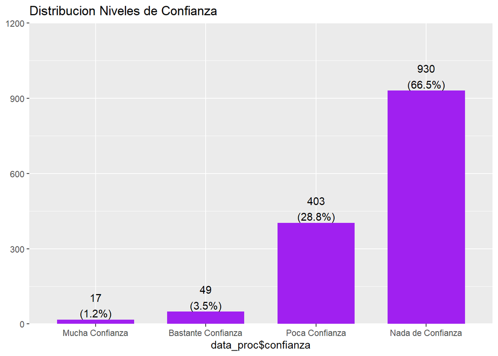

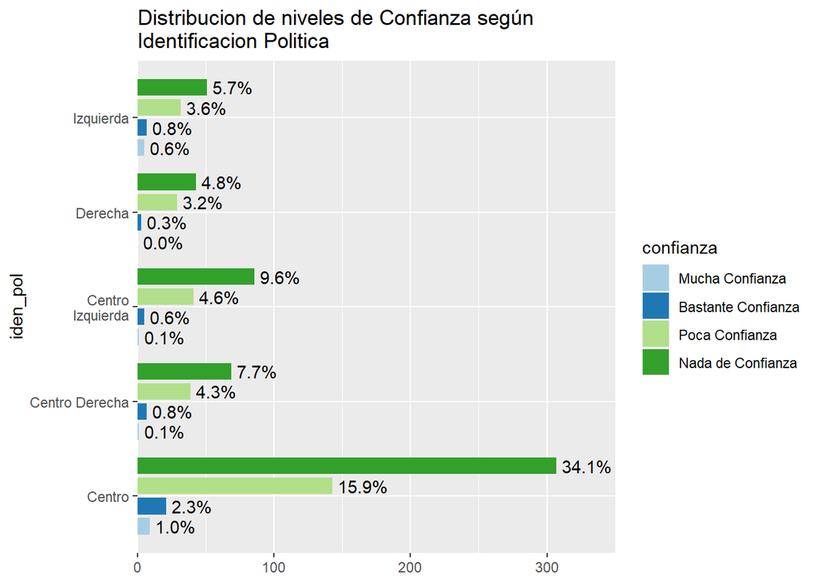

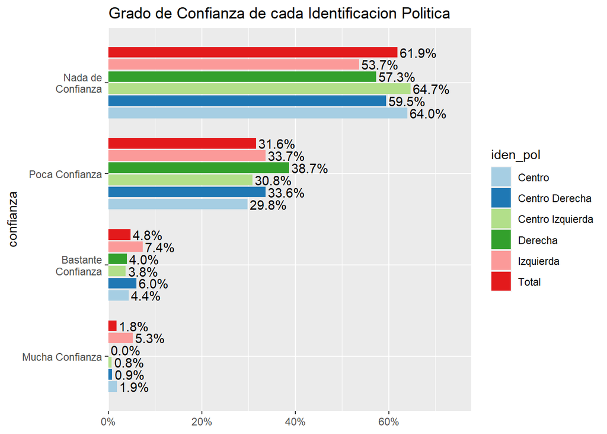

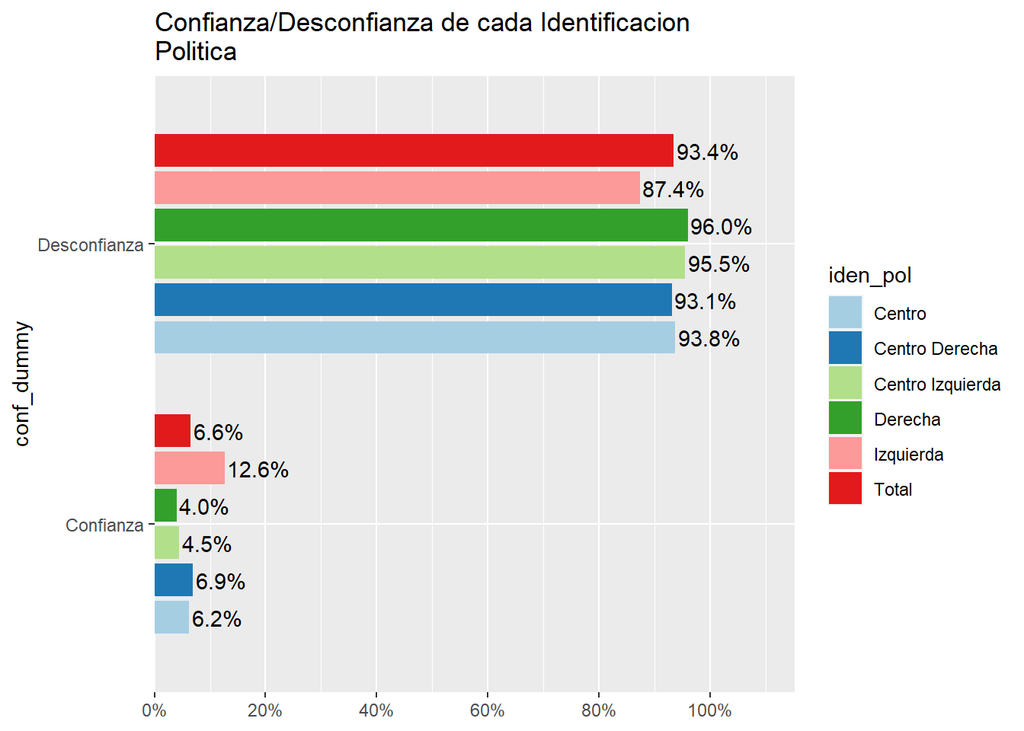

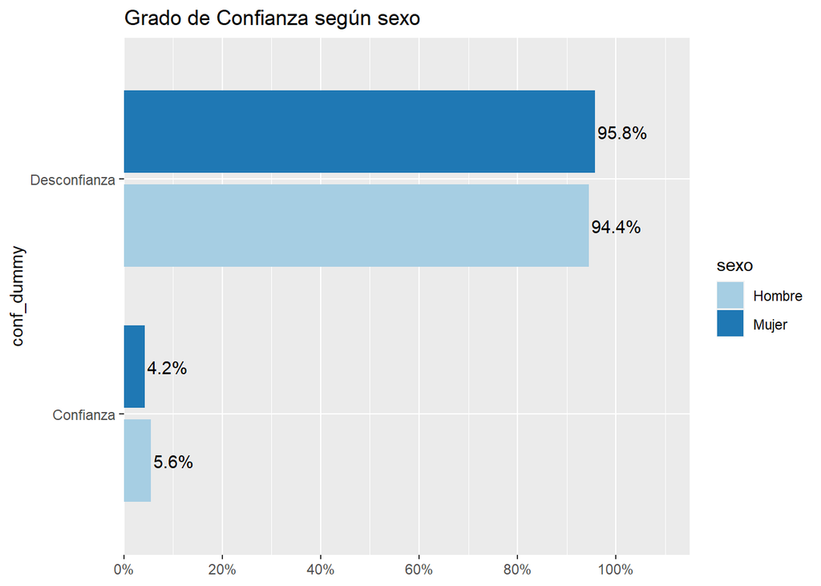

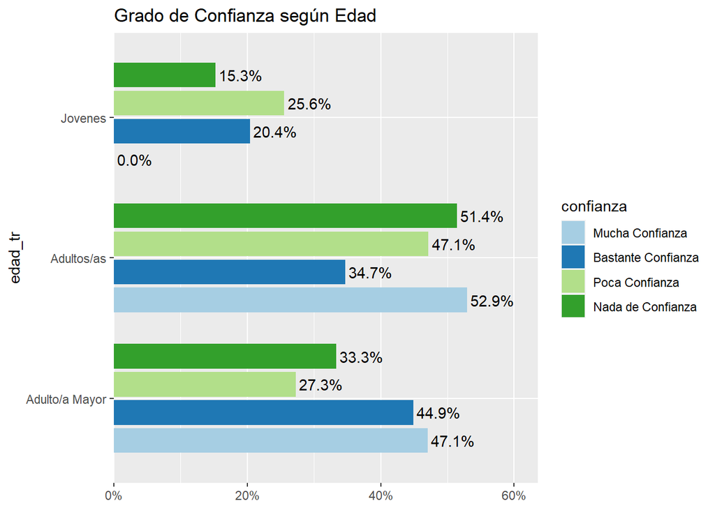

Tabla de Contingencia: Grado confianza según identificacion politica

| confianza | iden_pol |  |  |  |  | Total |  |
| --- | --- | --- | --- | --- | --- | --- | --- |
|  | Centro | Centro Derecha | Centro Izquierda | Derecha | Izquierda |  |  |
| Mucha Confianza | 9 56.2 % 1.9 % | 1 6.2 % 0.9 % | 1 6.2 % 0.8 % | 0 0 % 0 % | 5 31.2 % 5.3 % |  | 16 100 % 1.8 % |
| Bastante Confianza | 21 48.8 % 4.4 % | 7 16.3 % 6 % | 5 11.6 % 3.8 % | 3 7 % 4 % | 7 16.3 % 7.4 % | 43 100 % 4.8 % |  |
| Poca Confianza | 143 50.4 % 29.8 % | 39 13.7 % 33.6 % | 41 14.4 % 30.8 % | 29 10.2 % 38.7 % | 32 11.3 % 33.7 % | 284 100 % 31.6 % |  |
| Nada de Confianza | 307 55.2 % 64 % | 69 12.4 % 59.5 % | 86 15.5 % 64.7 % | 43 7.7 % 57.3 % | 51 9.2 % 53.7 % | 556 100 % 61.8 % |  |
| Total | 480 53.4 % 100 % | 116 12.9 % 100 % | 133 14.8 % 100 % | 75 8.3 % 100 % | 95 10.6 % 100 % | 899 100 % 100 % |  |

| Variable | Etiqueta | n | Media | D. estandar | Mediana | Rango |
| --- | --- | --- | --- | --- | --- | --- |
| edad | ¿Cuál es su edad? EDAD EXACTA | 1443 | 49.51698 | 18.31634 | 49 | 77 (18-95) |

Fuente:  
Elaboración propia en base a CEP 85

```r
summary(data_proc$edad) #Cuartiles + Media + Mediana Edad
```

```
##    Min. 1st Qu.  Median    Mean 3rd Qu.    Max.
##   18.00   34.00   49.00   49.52   64.00   95.00
```

```r
mlv(data_proc$edad, method = "mfv", na.rm = T) #Moda Edad
```

```
## [1] 56
```

Resultados: Con un 95,3% de porcentaje acumulado entre las variables nada de confianza y poca confianza, interpretamos un resultado positivo en funcion de nuestra hipotesis con respecto a los porcentaje de desconfianza se reconoce un severo problema dentro de la sociedad la que trae condigo una consecuencia anomica